# US Aircraft Registration by FAA

DataBauHeini, WhyKiki

September 18, 2021

## General Infos

### Abbreviations

Variable names were designed without dots to avoid conflicts within SQL statement(s). Following abbreviations were used as part of column names:

*ACFT*: Aircraft, *df_*: Dataframe, *HP*: Horsepower, *MFR*: Manufacturer, *No.*: Number, *v_*: Vector

### Files

This project covers various topics which were split to different scripts:

| Topic | Script |
| --- | --- |
| data preparation and preprocessing | AircraftRegistration_data.R |
| visualization and linear regression | AircraftRegistration_plots.R |
| shiny app (word clouds, tables) | app.R |

## About the Project

The main goal of this project was to improve our beginner’s capabilities in R. Therefore, we analyzed US aircraft registrations by Federal Aviation Admission. A specific goal was to analyze type and owner per aircraft registration and present our descoveries to the audience.  
**Or do you have an idea how many aircrafts with what kind of specifications are registred in the land of the free?**

## Data

### Data Source

Data was downloaded as zip file from the *Federal Aviation Administration* (FAA) [website](https://www.faa.gov/licenses_certificates/aircraft_certification/aircraft_registry/releasable_aircraft_download/) in August 2021. The zip file contained several text files that together could be used to build up a database. For this project, only the following files were used:

- master data (*MASTER.txt*)
- aircraft registration data (*ACFTREF.txt*)
- engine data (*ENGINE.txt*)  
  The whole dataset contains about 288 thousend entries. So at the time the set was created (27th of August 2021), there were that many aircrafts registred in the US. And those are all ‘civil’ ACFTs, because a list of the US Army-equipment is understandably not publicy available.

### Data Preprocessing

Selected columns from those files were read into R using different functions (`read.csv()`, `read.table()`, `read.delim()`):

```r
## read master dataset about aircraft (first 1000 rows): Approach 1 (read.csv())
master_selection <- c("MFR.MDL.CODE", "ENG.MFR.MDL", "YEAR.MFR", "TYPE.REGISTRANT",
                      "NAME", "CITY", "STATE", "CERTIFICATION", "EXPIRATION.DATE",
                      "ZIP.CODE", "COUNTRY", "TYPE.AIRCRAFT", "TYPE.ENGINE",
                      "LAST.ACTION.DATE")
df_master <- read.csv("MASTER.txt")[, master_selection]

## read dataset about aircraft engines: Approach 2 (read.table())
engine_selection <- c("CODE", "MFR", "MODEL", "TYPE", "HORSEPOWER", "THRUST")
df_engine <- read.table("ENGINE.txt", sep=",", header=TRUE)[, engine_selection]

## read dataset about aircraft registration: Approach 3 (read.delim())
registration_selection <- c("CODE", "MFR", "MODEL", "TYPE.ACFT",
                            "NO.ENG", "NO.SEATS", "SPEED")
df_registration <- read.delim("ACFTREF.txt", sep=",", header=TRUE)[, registration_selection]
```

Those dataframes were left-joined using different functions (`merge()`, `left_join()`):

```r
## left join df_master and df_registration: Approach 1 (using merge function)
df_aircraft <- merge(df_master, df_registration, by.x="MFR.MDL.CODE", by.y="CODE", all.x=TRUE)

## left join newly created df_aircraft and df_engine: Approach 2 (using left_join function)
df_aircraft <- left_join(df_aircraft, df_engine, by=c("ENG.MFR.MDL"="CODE"))

# remove unnecessary data frames
rm(list = c("df_engine", "df_master", "df_registration"))
```

Date columns were converted from type integer to date type:

```r
## set date columns from int to date type
dateCols <- c("LAST.ACTION.DATE","EXPIRATION.DATE")
for (some_date in dateCols) {
  df_aircraft[[some_date]] <- as.Date(paste(df_aircraft[[some_date]]), format="%Y%m%d")
}
```

Rename columns for better differentiation:

```r
## Rename columns: Approach 1 (without function)
names(df_aircraft)[names(df_aircraft) == "MFR.x"] <- "MFR_ACFT"

## Rename columns: Approach 2 (using a function)
renameCols <- function(df, oldName, newName){
  names(df)[names(df) == oldName] <- newName
  return (df)
}
df_aircraft <- renameCols(df_aircraft, "MFR.y", "MFR_engine")
df_aircraft <- renameCols(df_aircraft, "MODEL.x", "MODEL_ACFT")
df_aircraft <- renameCols(df_aircraft, "MODEL.y", "MODEL_engine")
```

Change data type of registrants (from numeric to character):

```r
## change class of variables where necessary
df_aircraft$TYPE.REGISTRANT <- as.character(df_aircraft$TYPE.REGISTRANT)

## check if it is the right class
class(df_aircraft$TYPE.REGISTRANT)
```

```
## [1] "character"
```

Create vectors for decoding categorical features:

```r
v_type_Registrant <- c("Individual", "Partnership", "Corporation", "Co-Owned", "Government",
                       "LLC", "Non Citizen Corporation", "Non Citizen Co-Owned")

v_Certification <- c("Standart", "Limited", "Restricted", "Experimental", "Provisional",
                     "Multiple", "Primary", "Special Flight Permit", "Light Sport")

v_type_ACFT <- c("Glider", "Balloon", "Blimp/Dirigible", "Fixed wing single engine",
                 "Fixed wing multi engine", "Rotorcraft", "Weight-shift-control",
                 "Powered Parachute", "Gyroplane", "Hybrid Lift", "Other")

v_type_engine <- c("None", "Reciprocating", "Turbo-prop", "Turbo-shaft", "Turbo-jet",
                   "Turbo-fan", "Ramjet", "2 Cycle", "4 Cycle", "Unknown",
                   "Electric", "Rotary")
```

### Tables

```r
## variable for the "top ten"
nTop <- 10

## Aircraft Manufacturer
df_ACFT_TopList_MFR <- df_aircraft %>%
  group_by(MFR_ACFT) %>%
  filter(!is.na(MFR_ACFT)) %>%
  summarise(count_n=n()) %>%
  slice_max(count_n, n=nTop, with_ties=FALSE)

df_ACFT_TopList_MFR %>%
  kbl(caption="TOP TEN AIRCFRAFT MANUFACTURERS") %>%
  kable_styling()
```

TOP TEN AIRCFRAFT MANUFACTURERS

| MFR_ACFT | count_n |
| --- | --- |
| CESSNA | 73388 |
| PIPER | 44839 |
| BEECH | 17928 |
| CIRRUS DESIGN CORP | 6319 |
| BOEING | 6091 |
| MOONEY | 5378 |
| AERONCA | 3973 |
| BELL | 3178 |
| BOMBARDIER INC | 2707 |
| BELLANCA | 2701 |

The most popular producers of aircrafts in the US were found to be *Cessna*, *Piper* and *Beech*. These are manufacturer of rather small aircrafts with only a few seats. Later, this statement will be confirmed by another visualisation.

There is also a shiny-app, where three different word clouds represent the most frequent *cities*, *aircraft manufacturers* and *aircraft models*. In the file AircraftRegistration_data.R you will find additional top lists (aircraft model, engine manufacturer & series, owners).

#### Pivot table

Possible approaches to create a pivot table are shown below. We did not implement a pivot table in the shiny app because of performance issues. Nevertheless, the pivot approach might be helpful for various data analysis investigations.

```r
## lower code incl. outcommended lines makes a pivot table with dyplr package
df_pivot1 <- df_aircraft %>%
  select(STATE, MFR_ACFT, MODEL_ACFT, TYPE.ACFT) # %>%
# group_by(STATE, MFR_ACFT, MODEL_ACFT, ) %>%
# summarize(count_model = n())

df_pivot <- pivot_longer(df_pivot1,
                         cols = c("STATE"),
                         names_to = "category",
                         values_to = "state")
head(df_pivot, n=10)
```

[output not shown]

### Plots

The dataset was explored visually first. The most convinient way was to use simple scatter plots.

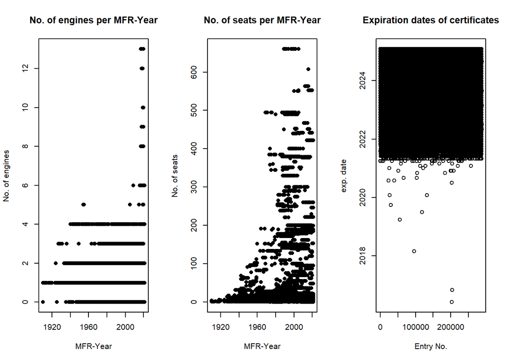

```r
df_yr_filt <- filter(df_aircraft, YEAR.MFR > 1900 & !is.na(YEAR.MFR))

par(mfrow=c(1,3))
## plot no. of engines over MFR-Year, incl. filter all NAs and wrong inputs (<4 digits)
plot(x = df_yr_filt$YEAR.MFR, y = df_yr_filt$NO.ENG, pch = 16,
     main = "No. of engines per MFR-Year", xlab = "MFR-Year", ylab = "No. of engines")

## plot no. of seats per MFR-year
plot(x = df_yr_filt$YEAR.MFR, y = df_yr_filt$NO.SEATS, pch = 16,
     main = "No. of seats per MFR-Year", xlab = "MFR-Year", ylab = "No. of seats")

## plot expiring certificates
plot(df_aircraft$EXPIRATION.DATE,
     main = "Expiration dates of certificates", xlab = "Entry No.", ylab = "exp. date")
```

The plot on the left strengthens the assumption, that most planes are small ones with one engine (= low number of seats). Most of the aircrafts with more than 8 engines are experimental ones. This can be simply approved by sorting the original dataframe by number of engines in descending order.  
Another interesting view on the dataset is, that the number of seats rise exponentially the newer the aircrafts are.  
The plot on the right shows something related to a clean database. There are a few entries, which are expired and some already for a long time. How is this possible in such a highly secure sector as aviation?

#### Use-case for optimisation

Depending on how the FAA operates, optimisation could be used on the expiring certificates:

1. If they inform the certificate owner with manual processes (look for expiring cert., create and send an information letter), they could plan the work load of the administrative employee.
2. Another approach is to model the expecting registrations (out of the behavior of the registrants until now) and from this to optimise future workload including planning of the staff.

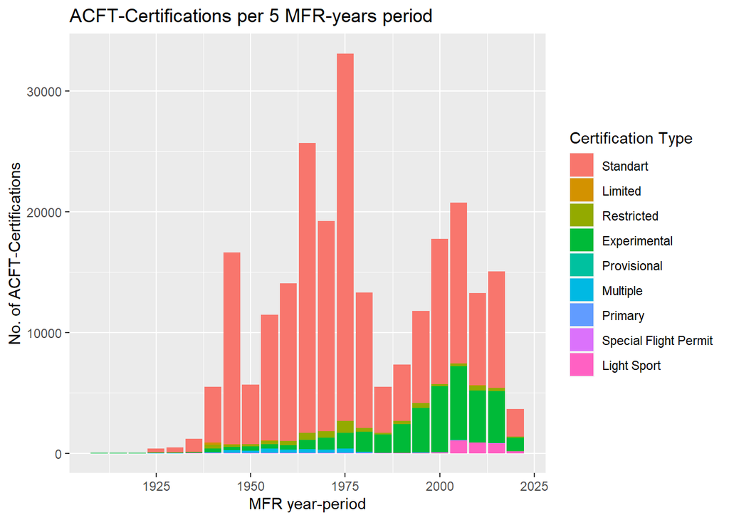

Most registred aircrafts were produced between 1970 and 1975. There is a remarkable drop in the number of aircrafts from 1980 to 1990. The reason for this needs to be further studied. There are also a lot of old experimental planes registered.  
This might be caused by the fact that it is harder to find certificated spare parts especially for oldtimers. Consequently, those were repaired with replicated parts and the experimental status preserves the airworthiness.

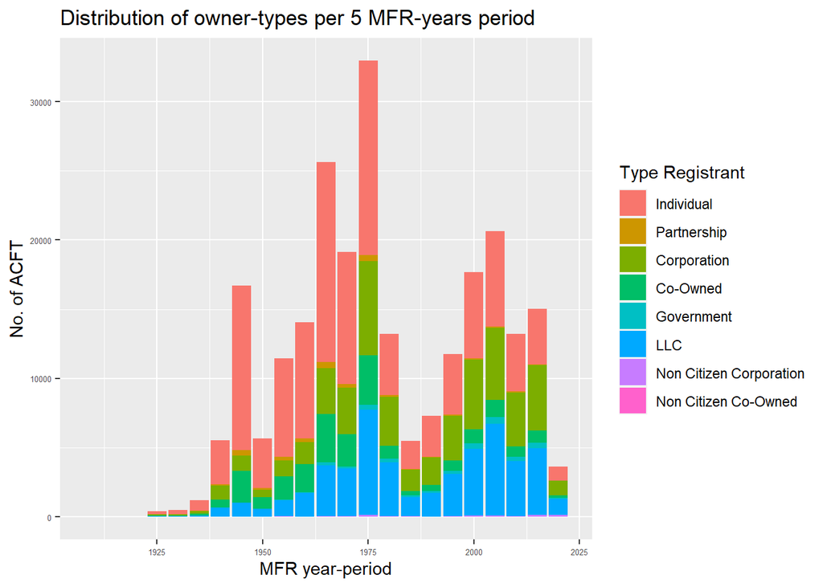

The mentioned drop in the number of aircrafts from 1980 to ’90 is also visible in the number of individual registrants (and others). Maybe those aircrafts are not so interesting for private owners (low HP, unreliable, value-unstable).

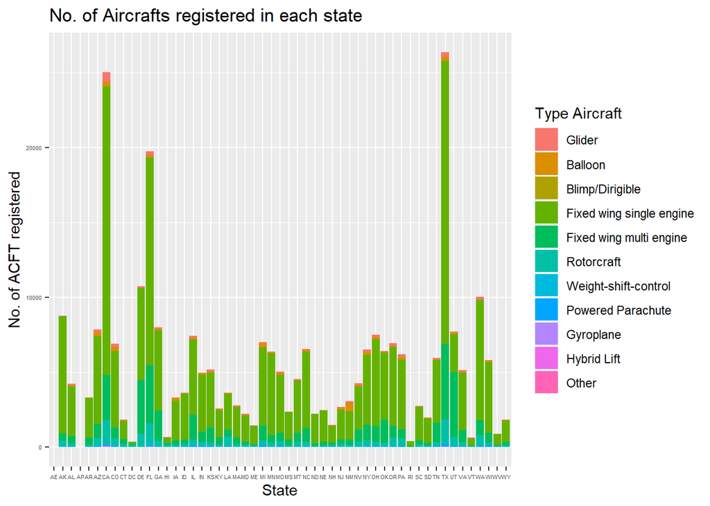

```r
## an example code of plotting barcharts
ggplot(df_ACFTNo_State, aes(x=STATE, y=count_ac)) +
  geom_bar(stat="identity", aes(fill=TYPE.ACFT)) +
  xlab("State")  +
  ylab("No. of ACFT registered") +
  ggtitle("No. of Aircrafts registered in each state") +
  scale_fill_discrete(name = "Type Aircraft",
                      labels = v_type_ACFT) +
  theme(axis.text = element_text(size = 4.1))
```

There are three states where a lot of aircrafts are registred: California, Florida and Texas. Besides *Rotorcraft* there are also much more aircrafts of the type ‘fixed wing multi engine’ registred. One reason could be that there are the most known rocket launch sides (e.g. Cape Canaveral FL, Vandenberg Space Force Base CA). From this point of view it might be concluded that there are big research companies which also research on other aviatic equipment besides rockets.  
But in those three states there are also a lot of ‘fixed wing single engine’ aircrafts registred. It could also be an indicator for wealthy population.

On the next plot we will have a closer look on experimental planes:

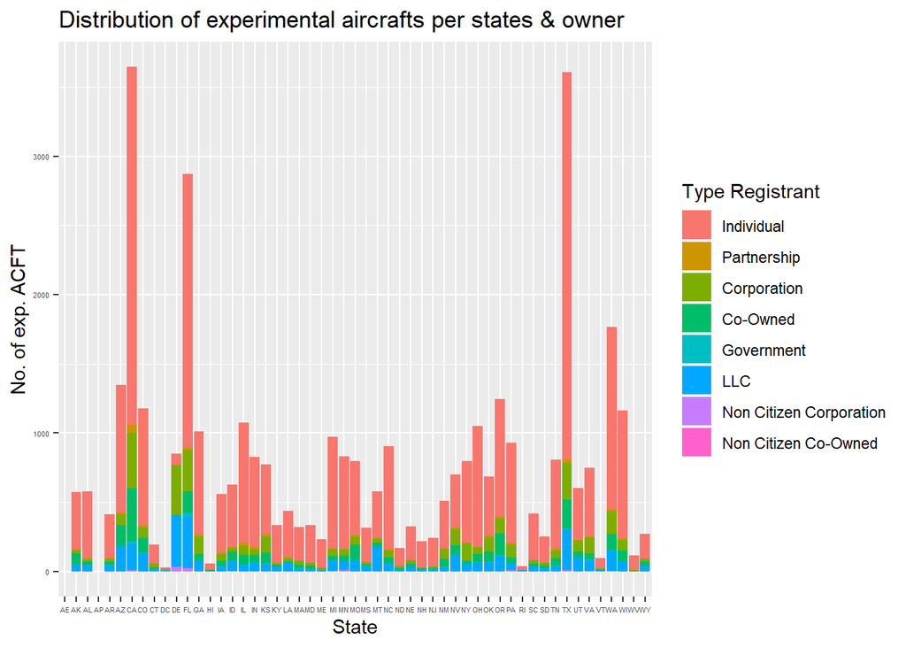

### Boxplots

In this chapter we visualized data using boxplots. First a exemplary code how boxplots are generated. Now the manufacter-years were grouped to decades for better investigation.

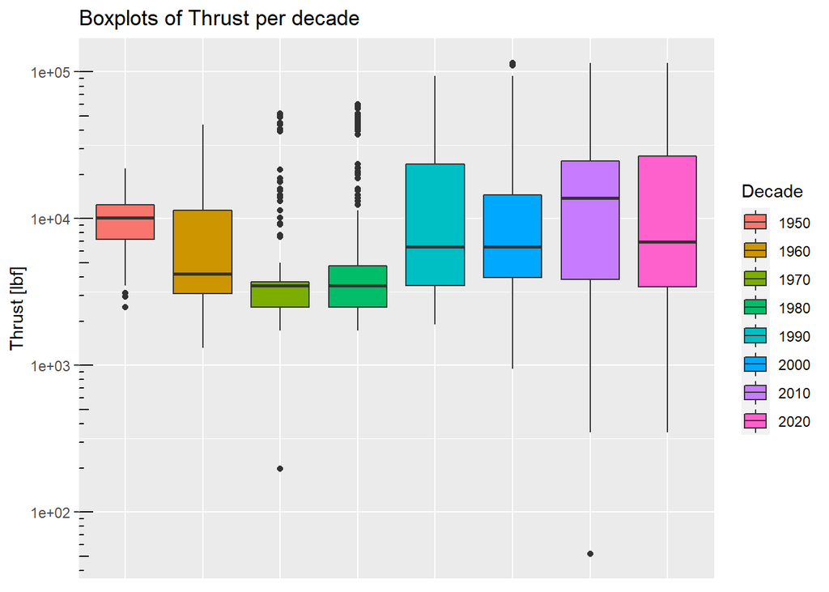

```r
## removed the x-axis, colored the boxes
ggplot(df_aircraft_MFR10Years_thrust, aes(x=YEAR.MFR10, y=THRUST, fill = YEAR.MFR10)) +
  geom_boxplot() +
  xlab("MFR decade") +
  ylab("Thrust [lbf]") +
  ggtitle("Boxplots of Thrust per decade") +
  scale_y_log10() +
  annotation_logticks(sides = c("l")) +
  scale_fill_discrete(name = "Decade") +
  theme(axis.title.x=element_blank(),
        axis.text.x=element_blank(),
        axis.ticks.x=element_blank())
```

The boxplot aboves showed us some statistical key-figures about the thrust of registred airplanes. There were only the decades from 1950 investigated, because of two reasons:

1. Jet engines were not used before ~1945.
2. Between 1945 and ’50 there are such a small number of aircrafts with jet engines (even during 1950s) so there wouldn’t be a useful insight.

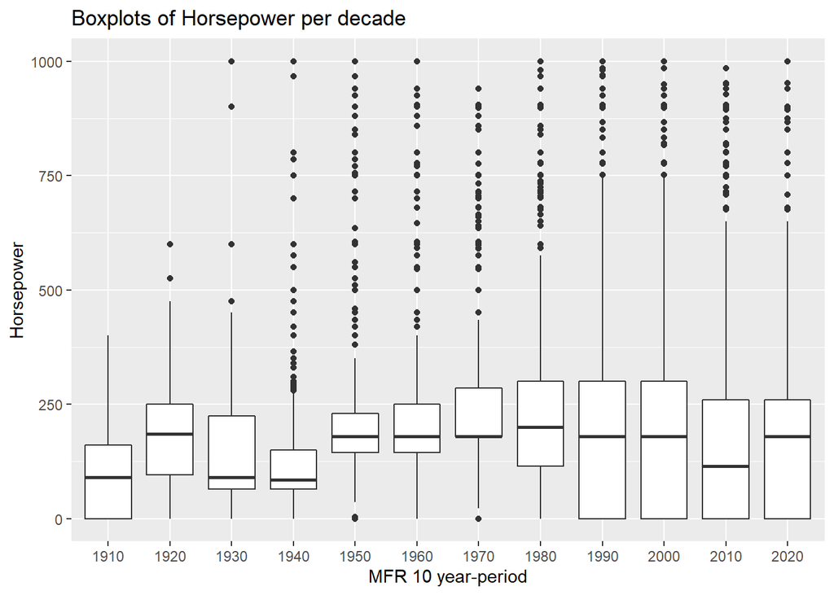

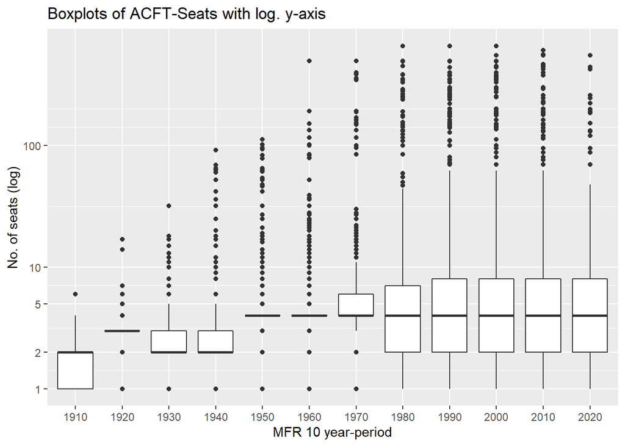

Until the 1950s, the mean number of seats were two (except in the ’20s). From the 1950s the mean was found to be four seats. So most of the regsitred aircrafts were are small planes or rotorcrafts. The highest number of seats is about 660. Those are mostly to be found on *Boeing 747*, also known as *JumboJet*.

#### View registrations per state in US map:

On the map below you can also see the distribution of aircraft registrations in the US. Owners from foreign countries were excluded.

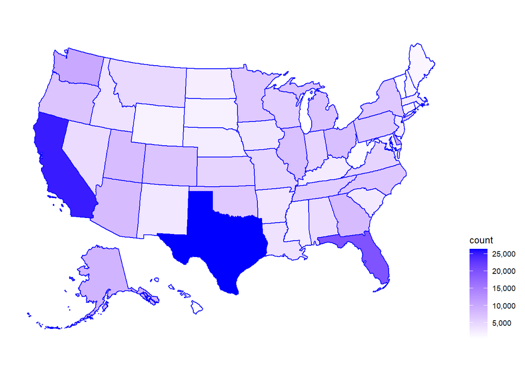

### Conclusions

This work gave some interesting insights into the *population* of aircrafts registered in the US. If this database was connected with others, lets say from company registrations or tax office, new regulations as well as better support of environmental protection are to be expected. Even connection to data from airplane crashes might improve flight security as this might be traced back to manufacturer or engine-specific defects. There is still a lot more to explore which needs to be postponed to future projects.